# Practical Machine Learning Course Project

Robert Mooney

Tuesday, May 19, 2015

# Introduction

The goal of this assignment is to develop an algorithm to predict if participants in a wearables study performed exercises correctly or incorrectly. There were five different ways a participant may have performed an exercise.

The training and test sets are found here: https://d396qusza40orc.cloudfront.net/predmachlearn/pml-training.csv https://d396qusza40orc.cloudfront.net/predmachlearn/pml-testing.csv

Descriptions of the sets and study can be found here: http://groupware.les.inf.puc-rio.br/har

Predictors may be any data in the dataset. The prediction variable is ‘classe’ variable, which is coded as any letter between A through E to represent the five different methods a participant could train.

# Discovery

Load the datasets. For now, leave stringsAsFactors to default as TRUE.

Eliminate columns that have NAs. There are lots of them:

```r
library(corrplot)
library(caret)
setwd("~/GitHub/MachineLearningProject")
train = read.csv('pml-training.csv')
test = read.csv('pml-testing.csv')

sumcols = colSums(is.na(train))

new.train = train[, (colSums(is.na(train)) == 0)]
new.test = test[, (colSums(is.na(train)) == 0)]
```

# Pre-Processing

Eliminate non-predictor variables such as user name, timestamp (unless we really think the time of day might impact things), and other non-relevant variables. Ensure that we impact train and test in the same manner.

```r
include.cols <- c("roll_belt", "pitch_belt", "yaw_belt", "total_accel_belt",
    "gyros_belt_x", "gyros_belt_y", "gyros_belt_z", "accel_belt_x", "accel_belt_y",
    "accel_belt_z", "magnet_belt_x", "magnet_belt_y", "magnet_belt_z", "roll_arm",
    "pitch_arm", "yaw_arm", "total_accel_arm", "gyros_arm_x", "gyros_arm_y",
    "gyros_arm_z", "accel_arm_x", "accel_arm_y", "accel_arm_z", "magnet_arm_x",
    "magnet_arm_y", "magnet_arm_z", "roll_dumbbell", "pitch_dumbbell", "yaw_dumbbell",
    "total_accel_dumbbell", "gyros_dumbbell_x", "gyros_dumbbell_y", "gyros_dumbbell_z",
    "accel_dumbbell_x", "accel_dumbbell_y", "accel_dumbbell_z", "magnet_dumbbell_x",
    "magnet_dumbbell_y", "magnet_dumbbell_z", "roll_forearm", "pitch_forearm",
    "yaw_forearm", "total_accel_forearm", "gyros_forearm_x", "gyros_forearm_y",
    "gyros_forearm_z", "accel_forearm_x", "accel_forearm_y", "accel_forearm_z",
    "magnet_forearm_x", "magnet_forearm_y", "magnet_forearm_z")
new.test = new.test[,include.cols]
new.train = new.train[,c(include.cols,'classe')]
```

This results in a simplified data set.

The training set is so large compared to the test set that it makes sense to create a validation set from it.

```r
inTrain = createDataPartition(y = new.train$classe, p = 0.7, list = FALSE)
trainSet = new.train[inTrain, ]
validationSet = new.train[-inTrain, ]
```

Look at highly correlated variables – these may be another opportunity for removal.

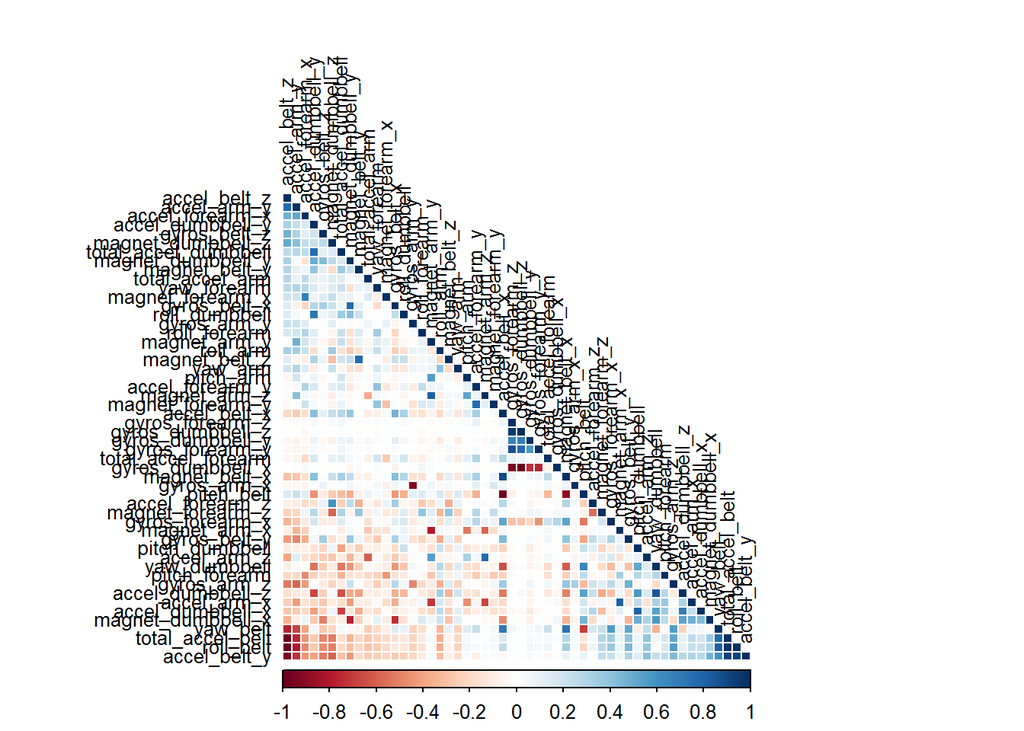

```r
corMatrix = cor(trainSet[, names(trainSet) != "classe"])
corrplot(corMatrix, order = "FPC", method = "color", type = "lower", tl.cex = 0.8,
    tl.col = rgb(0, 0, 0))
```

Dark blue and dark red indicate high positive and negative correlations. PCA can be used to extract more uncorrelated predictors.

```r
preProc = preProcess(trainSet[,names(trainSet) != "classe"], method = "pca", thresh = 0.99)
trainPC = predict(preProc, trainSet[, names(trainSet) != "classe"])
validPC = predict(preProc, validationSet[, names(trainSet) != "classe"])
```

Apply a random forest model on the training set. Cross validation is used in the trainControl() parameter.

```r
library(randomForest)
modelFit <- train(trainSet$classe ~ ., method = "rf", data = trainPC,
                  trControl = trainControl(method ="cv", number = 4), importance = TRUE)
# folds =4, which roughly means 25% of the data will be used to evaluate in the cross validation
```

Plot importance of individual components in the trained model:

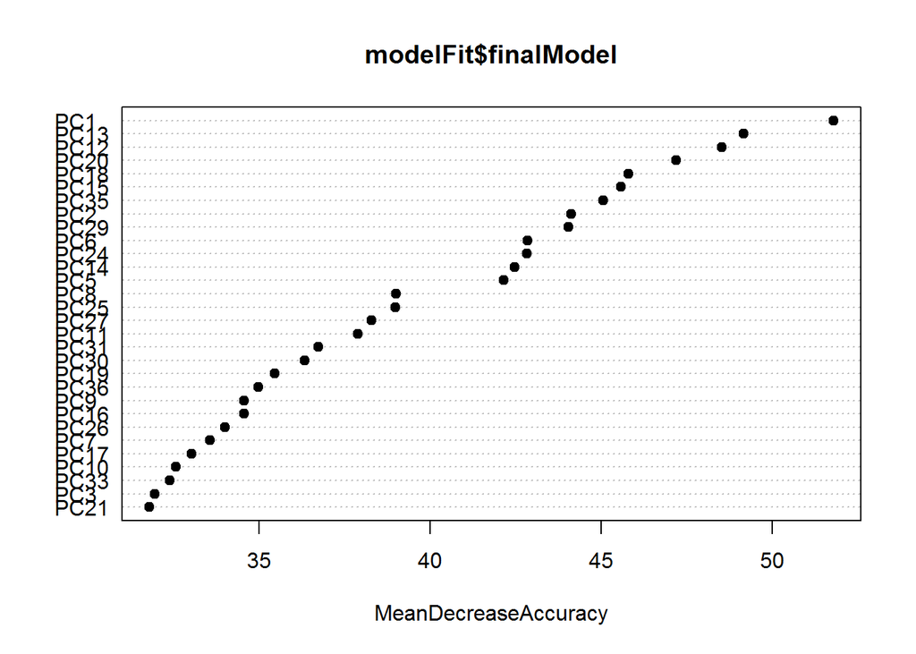

```r
varImpPlot(modelFit$finalModel, sort = TRUE, type = 1, pch = 19, col = 1, cex = 1)
```

Points that score high in the importance of the model are listed first with values high on the x-axis. It looks like we could still prune our model further if we feared too much overfitting by cutting out the bottom 2-3 variables.

# Validation and Out of Sample Error

We saved some data for validation. We should use it:

```r
pred.valid <- predict(modelFit, validPC)
confusionMatrix(validationSet$classe, pred.valid)
```

```
## Confusion Matrix and Statistics
##
##           Reference
## Prediction    A    B    C    D    E
##          A 1671    1    0    2    0
##          B   29 1098   11    0    1
##          C    1   20  999    6    0
##          D    1    0   43  918    2
##          E    0    1   16    7 1058
##
## Overall Statistics
##
##                Accuracy : 0.976
##                  95% CI : (0.9718, 0.9798)
##     No Information Rate : 0.2892
##     P-Value [Acc > NIR] : < 2.2e-16
##
##                   Kappa : 0.9697
##  Mcnemar's Test P-Value : NA
##
## Statistics by Class:
##
##                      Class: A Class: B Class: C Class: D Class: E
## Sensitivity            0.9818   0.9804   0.9345   0.9839   0.9972
## Specificity            0.9993   0.9914   0.9944   0.9907   0.9950
## Pos Pred Value         0.9982   0.9640   0.9737   0.9523   0.9778
## Neg Pred Value         0.9926   0.9954   0.9856   0.9970   0.9994
## Prevalence             0.2892   0.1903   0.1816   0.1585   0.1803
## Detection Rate         0.2839   0.1866   0.1698   0.1560   0.1798
## Detection Prevalence   0.2845   0.1935   0.1743   0.1638   0.1839
## Balanced Accuracy      0.9905   0.9859   0.9645   0.9873   0.9961
```

```r
accuracy = sum(pred.valid == validationSet$classe)/length(pred.valid)
1-accuracy
```

```
## [1] 0.02395922
```

# Predictions

Predict the answers, list,and prep for uploading to Coursera.

```r
testPC = predict(preProc, new.test)
pred.test = predict(modelFit,testPC)
pred.test
```

```
##  [1] B A B A A E D B A A B C B A E E A B B B
## Levels: A B C D E
```

```r
pml_write_files = function(x){
  n = length(x)
  for(i in 1:n){
    filename = paste0("problem_id_",i,".txt")
    write.table(x[i],file=filename,quote=FALSE,row.names=FALSE,col.names=FALSE)
  }
}

pml_write_files(pred.test)
```